# Tidying & Visualizing Data

`ggplot2` has a number of scale options for all of its aesthetics. We’ll re-scale x and y using `scale_x_log10` and `scale_y_log10`:

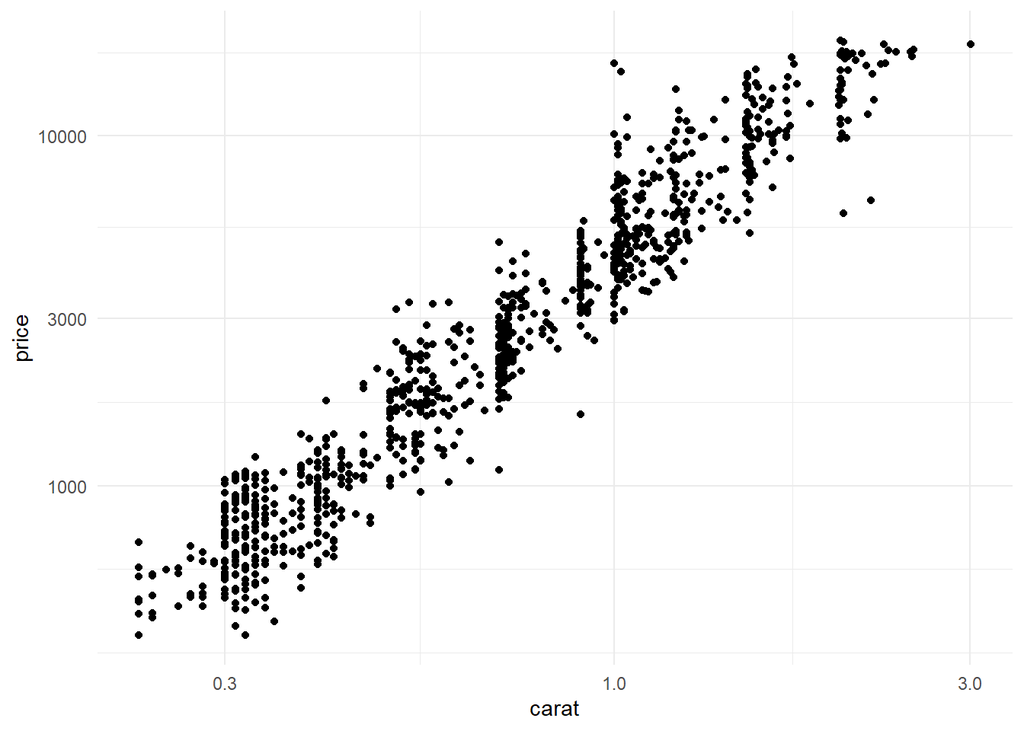

```r
ggplot(diamonds, aes(x = carat, y = price)) +
  geom_point() +
  theme_minimal() +
  scale_x_log10() +
  scale_y_log10()
```

You can also change the scale of other aesthetics too. For example, let’s color points by diamonds’ cut:

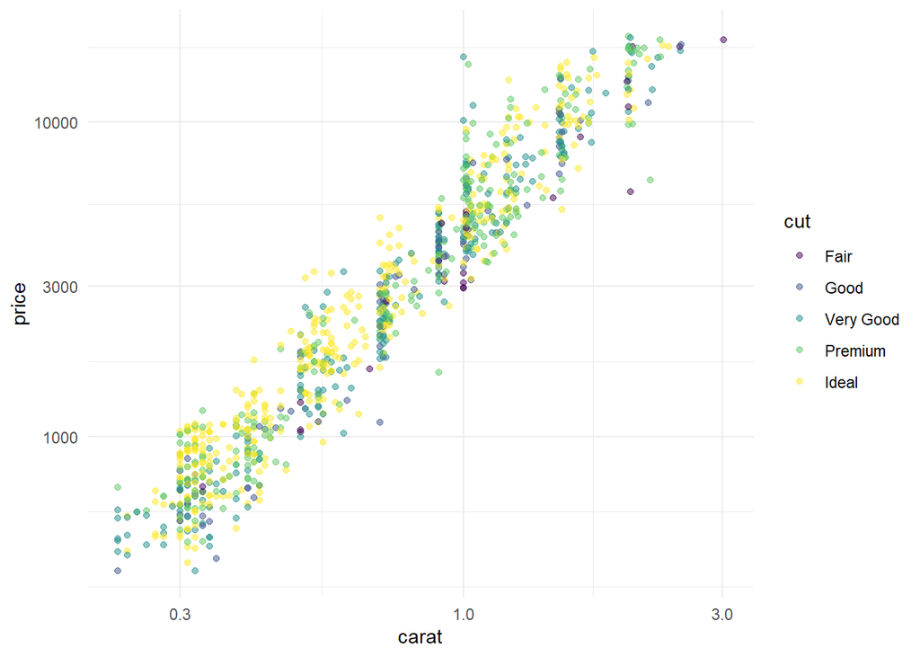

```r
ggplot(diamonds, aes(x = carat, y = price, color = cut)) +
  geom_point(alpha = .5) + # changing alpha bc of overlap
  theme_minimal() +
  scale_x_log10() +
  scale_y_log10()
```

And then we could change that using `scale_color_brewer()` and setting the pallete to something else. We can see its options by checking out the help documentation:

```r
?scale_color_brewer
```

Let’s set it to set1:

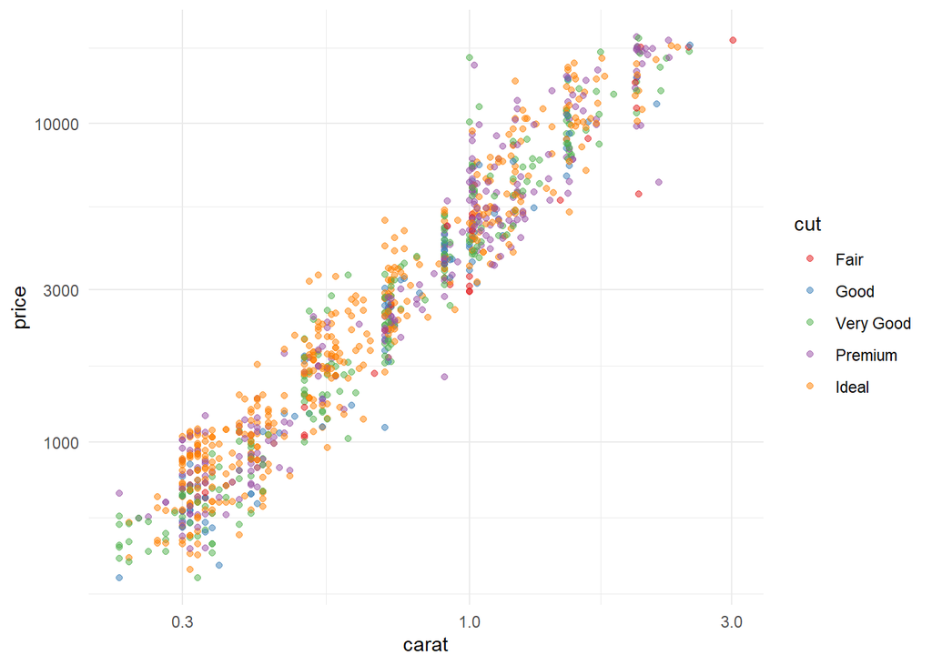

```r
ggplot(diamonds, aes(x = carat, y = price, color = cut)) +
  geom_point(alpha = .5) + # changing alpha bc of overlap
  theme_minimal() +
  scale_x_log10() +
  scale_y_log10() +
  scale_color_brewer(palette="Set1")
```

Or we could change it to another palette:

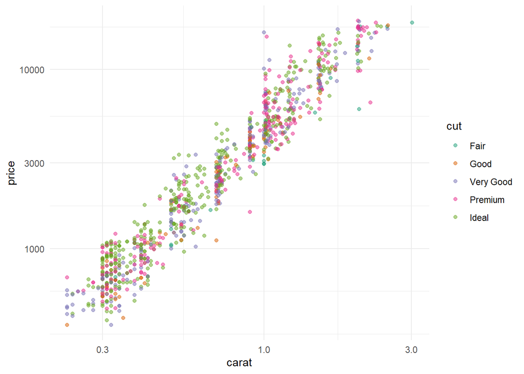

```r
ggplot(diamonds, aes(x = carat, y = price, color = cut)) +
  geom_point(alpha = .5) + # changing alpha bc of overlap
  theme_minimal() +
  scale_x_log10() +
  scale_y_log10() +
  scale_color_brewer(palette="Dark2")
```

# Final Exercise!

> For our last exercise, we’ll do something a little more fun. I want you to use the tools we’ve covered today to make the ugliest plot possible. Some things that might help:
> - Mixing unrelated datasets together using geom-level data
> - Using aesthetics in a weird way
> - altering the theme

> Get creative and have fun with it! This is a great way to find out more about ggplot, and maybe find out some things you shouldn’t do (hint: try using geom_line()).